# Assignment 4

Aigerim Kulzhabayeva

4 June 2019

### EXERCISE:

- Plot random effects against variables you feel might reveal a pattern
- Experiment with the alternative RE model.

We will generate random effects from the following model

```r
fitc <- lme( mathach ~ (ses + ses.m) * Sector, dd,
             random = ~ 1 + ses | school )
rand.eff<-ranef(fitc)
```

### 1.Plot of random effect of ses and the random intercept

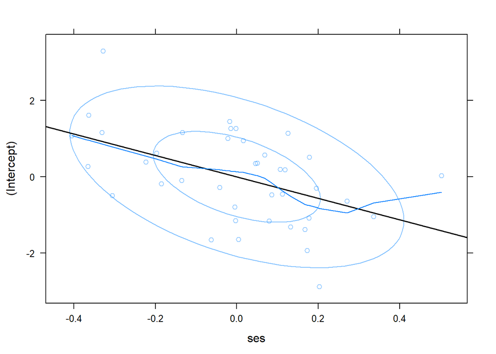

There is a negative linear relationship between the intercept and the effect of ses on the math achievement. There is one influential outlier, without it the relationship might be even stronger.

### 2. Following are the plots of random effects against school size, proportion of sexes, sector and proportion of minority groups.

#### a) School size

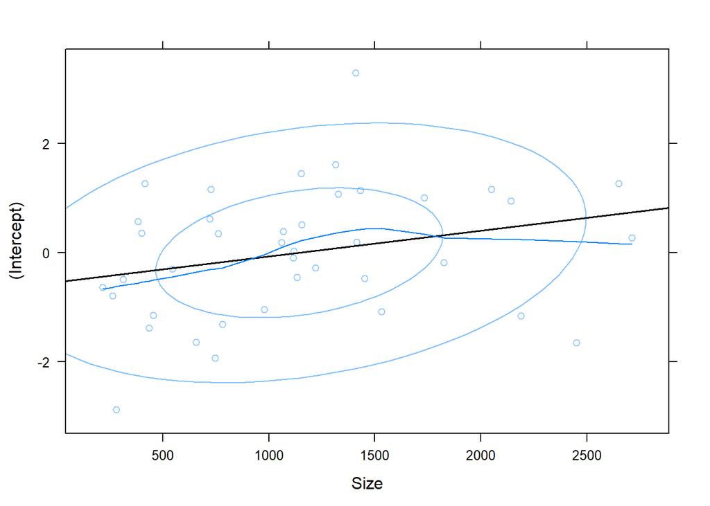

It seems for largers schools the intercept tends to be higher, however there a few outliers that may affect the fit.

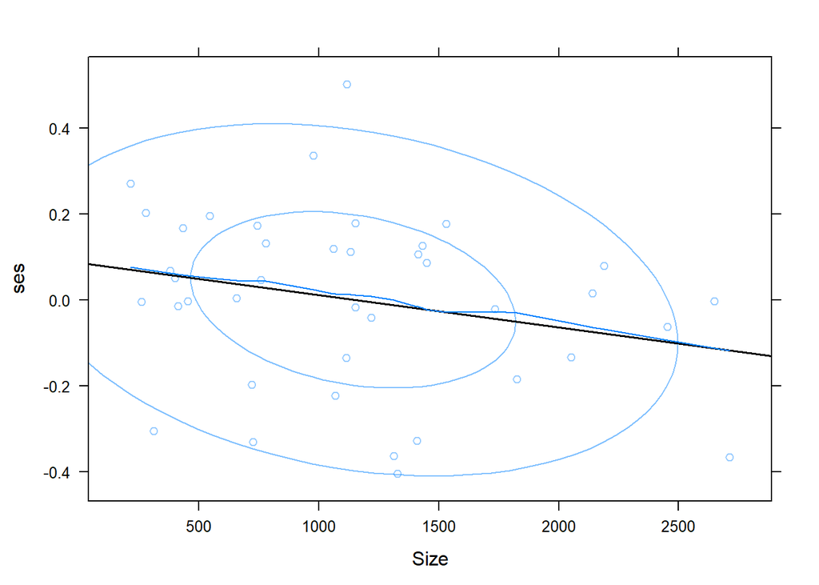

For larger schools effect of ses tends to become negative,but again there is an outlier that may affect the fit

#### b) Sex

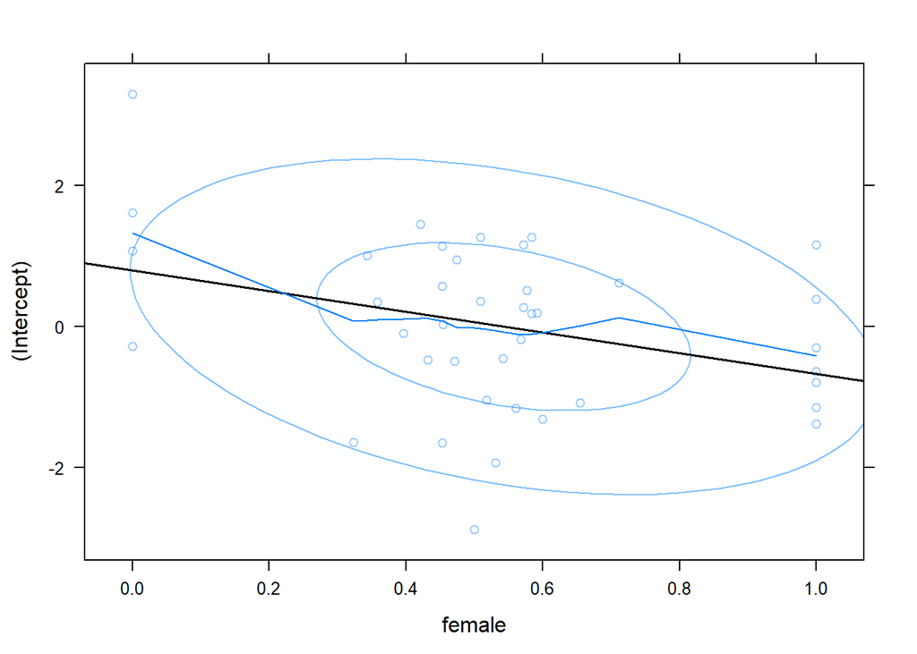

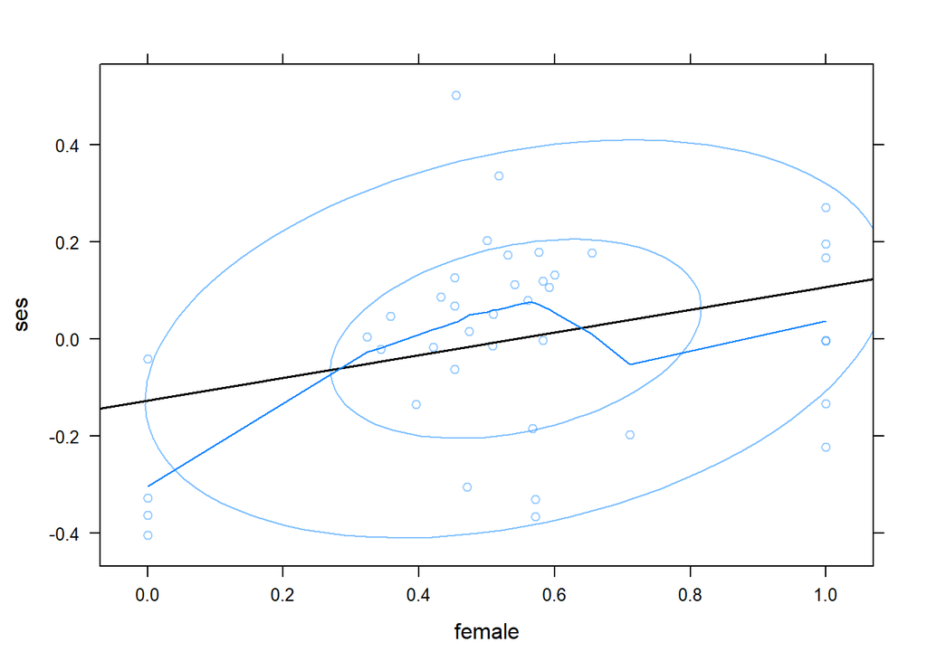

The regression line in these graphs is meaningless since single gender schools are categorically different form mixed gender schools. But if we look at them separetly we can see that effect of ses is much greater in girl schools and is positively related to proportion of girls in mixed schools. Random intercept is however is lower for girl schools and is negatively related to the proportion of girls in mixed schools.

#### c) Sector

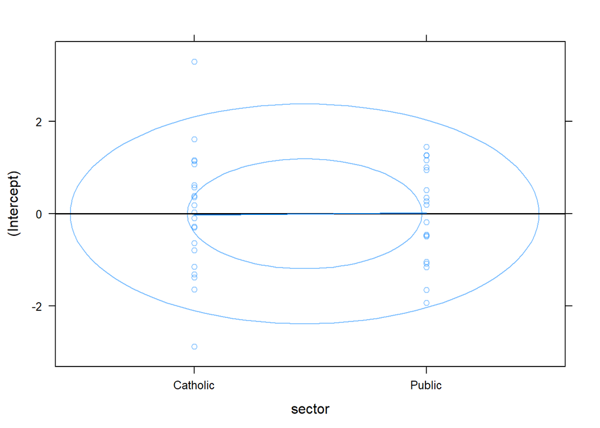

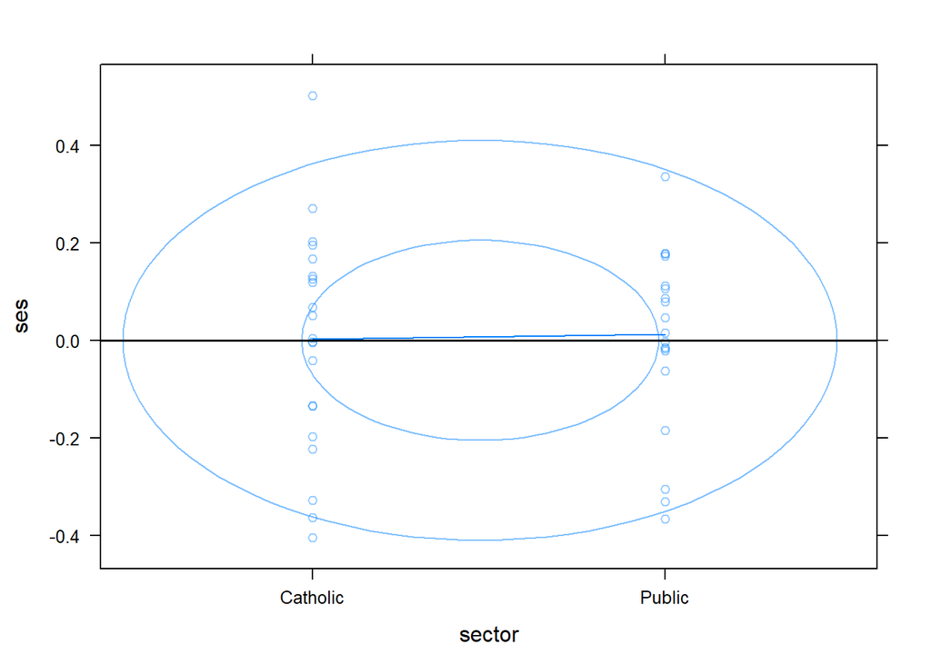

#### d) Minority groups

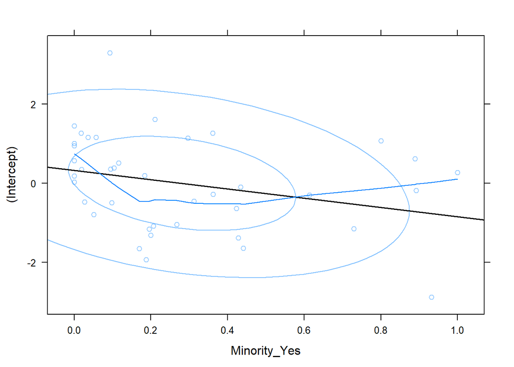

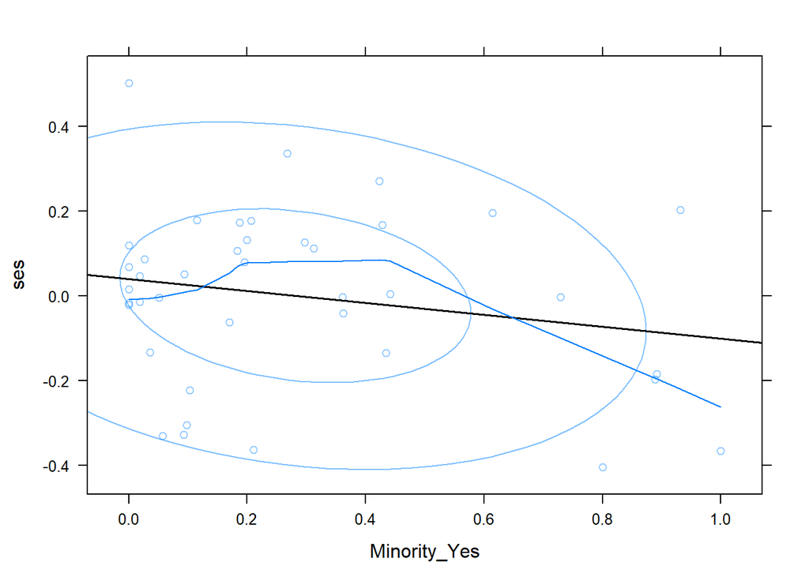

It seems with higher the proportion of students from minority groups, the random intercept becomes less. This means that math achivement scores are generally lower. However there is a cluster of four outliers that have higher intercept and mostly minority students.

With increasing proportion negative effect of ses on math achivement increases, however the same four scools are dragging the regression line down. It would be interesting to look at those schools closer.

### 3. Lets change the random effects part of the model and see if anything changes.

In particular we will substitute ses with dvar(ses,id) which will give centeres within group variable.

```r
fitc_dvar <- lme( mathach ~ (ses + ses.m) * Sector, dd,
             random = ~ 1 + dvar(ses,school) | school )


summary(fitc)
```

```
## Linear mixed-effects model fit by REML
##  Data: dd
##       AIC      BIC    logLik
##   12839.6 12895.47 -6409.801
##
## Random effects:
##  Formula: ~1 + ses | school
##  Structure: General positive-definite, Log-Cholesky parametrization
##             StdDev    Corr
## (Intercept) 1.4561519 (Intr)
## ses         0.5190639 -0.217
## Residual    6.1140010
##
## Fixed effects: mathach ~ (ses + ses.m) * Sector
##                        Value Std.Error   DF  t-value p-value
## (Intercept)        13.356053 0.3753744 1935 35.58062  0.0000
## ses                 1.699397 0.3095543 1935  5.48982  0.0000
## ses.m               2.407785 1.0629298   36  2.26523  0.0296
## SectorPublic       -0.934345 0.5628780   36 -1.65994  0.1056
## ses:SectorPublic    1.173092 0.4677016 1935  2.50821  0.0122
## ses.m:SectorPublic  1.414896 1.4652174   36  0.96566  0.3407
##  Correlation:
##                    (Intr) ses    ses.m  SctrPb ss:ScP
## ses                -0.071
## ses.m              -0.186 -0.248
## SectorPublic       -0.667  0.047  0.124
## ses:SectorPublic    0.047 -0.662  0.164 -0.065
## ses.m:SectorPublic  0.135  0.180 -0.725  0.056 -0.284
##
## Standardized Within-Group Residuals:
##         Min          Q1         Med          Q3         Max
## -3.09882513 -0.75336271  0.03194452  0.78173508  2.79671295
##
## Number of Observations: 1977
## Number of Groups: 40
```

```r
summary(fitc_dvar)
```

```
## Linear mixed-effects model fit by REML
##  Data: dd
##        AIC      BIC    logLik
##   12839.22 12895.09 -6409.612
##
## Random effects:
##  Formula: ~1 + dvar(ses, school) | school
##  Structure: General positive-definite, Log-Cholesky parametrization
##                   StdDev    Corr
## (Intercept)       1.4625200 (Intr)
## dvar(ses, school) 0.6802261 -0.071
## Residual          6.1084863
##
## Fixed effects: mathach ~ (ses + ses.m) * Sector
##                        Value Std.Error   DF  t-value p-value
## (Intercept)        13.374349 0.3732778 1935 35.82948  0.0000
## ses                 1.695976 0.3241495 1935  5.23208  0.0000
## ses.m               2.398991 1.0734653   36  2.23481  0.0317
## SectorPublic       -0.939334 0.5625274   36 -1.66985  0.1036
## ses:SectorPublic    1.171880 0.4888990 1935  2.39698  0.0166
## ses.m:SectorPublic  1.238194 1.4581049   36  0.84918  0.4014
##  Correlation:
##                    (Intr) ses    ses.m  SctrPb ss:ScP
## ses                -0.028
## ses.m              -0.159 -0.300
## SectorPublic       -0.664  0.019  0.106
## ses:SectorPublic    0.019 -0.663  0.199 -0.026
## ses.m:SectorPublic  0.117  0.221 -0.736  0.078 -0.336
##
## Standardized Within-Group Residuals:
##         Min          Q1         Med          Q3         Max
## -3.10199875 -0.75105077  0.03298316  0.78240512  2.80416484
##
## Number of Observations: 1977
## Number of Groups: 40
```

```r
rand.eff<-ranef(fitc_dvar)
```

The correlation between the intercept and dvar(ses,id) is much lower than just ses.

#### a) ses.cwc and intercept

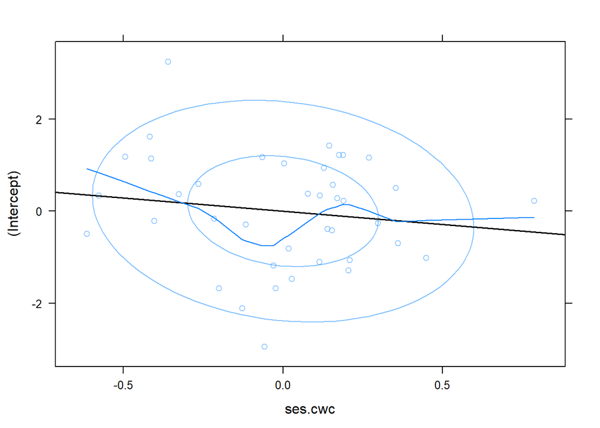

#### b) Size

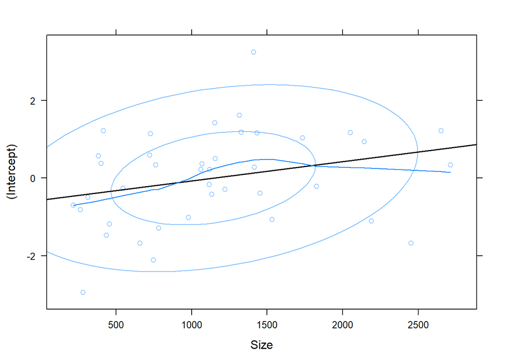

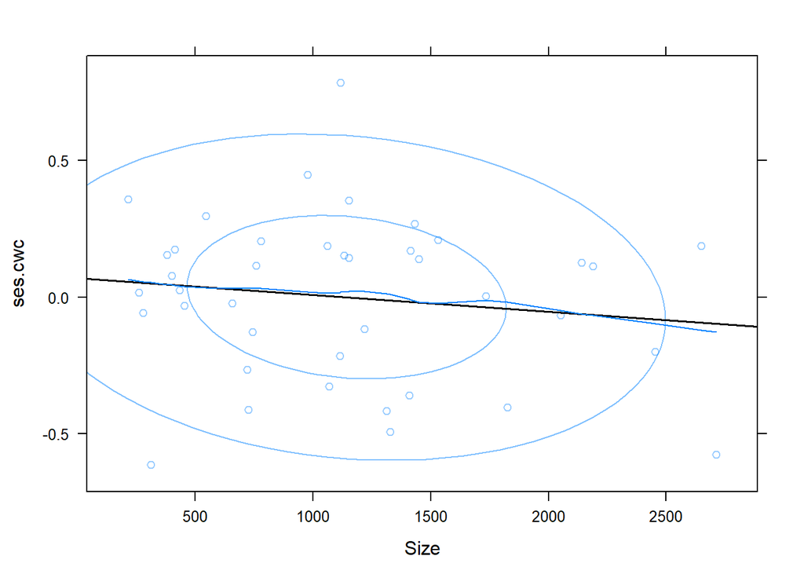

#### c) Sex

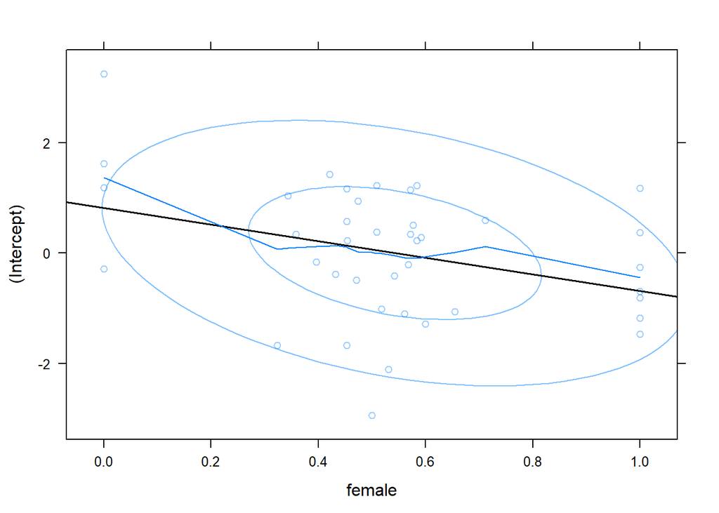

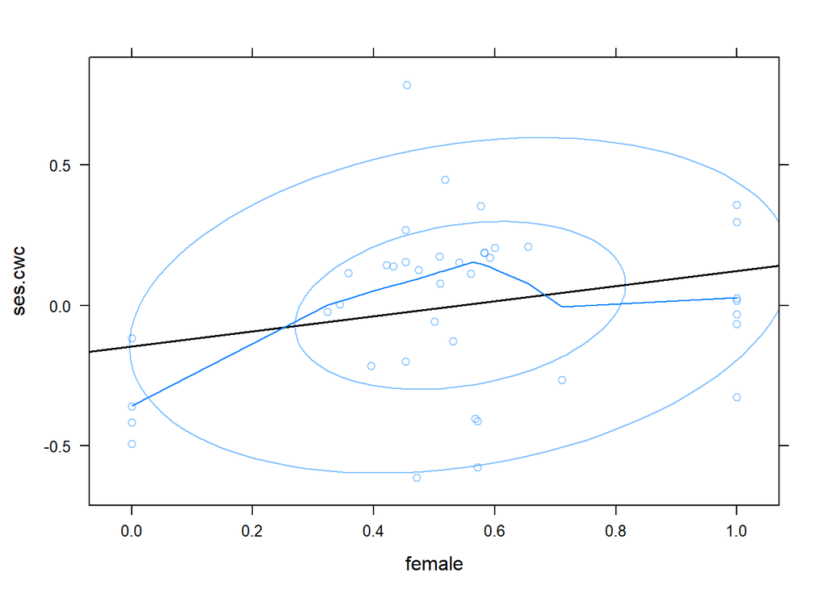

#### d) Sector

[figure not shown]

[figure not shown]

#### e) Minority

[figure not shown]

[figure not shown]

It seems the higher the proportion of students from minority groups,matachivement is generally less and higher the negative effect of ses on mathachivement

#### Conclusion

The resulting graphs of the random models looked alike but some relationships are sligtlly increased or decreased. However correlation between the intercept and effect of ses.cwc is much smaller which can help greatly for the convegence.

[output not shown]